# PRÁCTICA 1: MEDIDA DE PEQUEÑAS LONGITUDES Y DETERMINACIÓN DE DENSIDADES

**Autor responsable**: Pablo Corbalán de Concepción.

**Autores**: Pablo Corbalán de Concepción y Víctor Mula Navarro.

**Grupo**: G4 - DTIE+FÍSICA.

**Fecha del informe**: 12/02/2026.

## INFORMACIÓN GENERAL DEL LABORATORIO

**Fecha de realización de la práctica**: 29/01/26.

**Temperatura**: 20.0ºC.

**Presión**: 1013.7 HPa.

**Humedad relativa**: 57%.

## CARGA DE LIBRERÍAS EN PYTHON

```python
import matplotlib.pyplot as plt
import numpy as np
from scipy import stats
from scipy.optimize import curve_fit
from scipy.stats import t
```

# 1. INTRODUCCIÓN Y OBJETIVOS

Cada objeto tiene asociadas unas propiedades intrínsecas a él, como lo pueden ser su masa, volumen y densidad. Dichas magnitudes aportan gran información a la hora del estudio de objetos físicos. En un laboratorio, con la ayuda de los instrumentos adecuados es posible, dado un objeto concreto, hallar su masa, volumen y, por tanto, densidad de manera experimental.

En particular, se procederá al cálculo de la densidad de 3 objetos:

- **Cilindro metálico**: Elegimos un cilindro metálico para medir tanto su diámetro como su altura para hacer los cálculos pertinentes posteriormente.
- **Paralelepípedo metálico**: Tomamos un paralelepípedo y hacemos mediciones relativas a su ancho, alto y largo.
- **Placa delgada metálica**: Las medidas tomadas son análogas a las hechas en el paralelepípedo.

Por otro lado, cuando se trabaja con instrumentos de medida existe un margen de error determinado por la resolución del aparato. Este defecto se acentúa cuando los objetos a medir son pequeños con respecto a dicha resolución. Cuando esto ocurre, es conveniente medir a la vez varios objetos iguales para minimizar el error. En el caso particular de nuestro experimento, para determinar la densidad de una arandela metálica fina, apilaremos varias de ellas y efectuaremos las medidas sobre ellas. Posteriormente, extraeremos conclusiones que nos permitirán averiguar las propiedades de la arandela.

# 2. PROCEDIMIENTO Y MONTAJE EXPERIMENTAL

Como se ha mencionado anteriormente, el objeto de esta práctica será medir las longitudes y masas de los susodichos tres objetos así como de las arandelas con el fin de determinar sus densidades. Para la medida de las dimensiones del el cilindro, el paralelepípedo y la placa usaremos un pie de rey. Al tratarse de objetos cuyas dimensiones no se alejan en gran cantidad de la resolución del instrumento, las medidas tomadas serán fidedignas en su mayoría. Así pues, empleamos dicho aparato correctamente y recabamos la información sobre las dimensiones de los objetos para anotarlas en tablas de resultados posteriormente. Análogamente, haremos uso de una balanza digital para determinar sus masas. Una vez disponemos de toda esta información, utilizaremos las siguientes fórmulas matemáticas para hallar la densidad.

Para el cilindro, sean $h$ su altura, $d$ su diámetro; para la placa y el paralelepípedo, sean $x$ su ancho, $y$ su largo y $z$ su alto. Entonces: $$\begin{cases} V_{cilindro} = \frac{\pi}{4}h\cdot d^2\\ V_{placa} = x\cdot y \cdot z\\V_{paralelepípedo} = x \cdot y \cdot z\end{cases}$$

Sabido esto, y si suponemos que la distribución de masas en los materiales es homogénea, la fórmula para el cálculo de densidad es común a todas las figuras:

$$ \rho = \frac{m}{V} \tag{1} $$

Con respecto a las arandelas, para medir sus radios tanto interior como exterior volveremos a hacer uso del pie de rey. No obstante, para medir el espesor recurriremos al micrómetro, herramienta mucho más precisa que el pie de rey, indicada para la medición de longitudes pequeñas. Anotaremos el espesor tanto de una arandela como de 10 de ellas. Para la masa, recabaremos, con la ayuda de la balanza, la masa de 0, 5, 10, 15, 20, 25, 30 arandelas. Posteriormente, se estimará la masa por regresión lineal, considerando la ecuación $$ m_n = m_1\cdot n \tag{2}$$

donde n es el número de arandelas y m la masa en gramos. La pendiente de dicha recta será la masa de una arandela, que es el dato buscado.

No obstante, será preciso tener en cuenta la propagación de incertidumbres a la hora de calcular tanto el volumen como la densidad. La incertidumbre asociada al cálculo del volumen del paralelepípedo y la placa es

$$\left(\frac{u_V}{\overline{V}}\right)^2 = \sum_{k=x,y,z}\left(\frac{u_k}{\overline{k}}\right)^2$$

Si nos referimos al volumen del cilindro:

$$ {\left(\frac{u_V}{V}\right)}^2 = {\left(2\frac{u_d}{d}\right)}^2 + {\left(\frac{u_h}{h}\right)}^2 \tag{4}$$

En cuanto a la densidad de cualquiera de las figuras:

$$\left( \frac{u_{\rho}}{\rho} \right)^2 = \left( \frac{u_m}{m} \right)^2 + \left( \frac{u_V}{V} \right)^2 \tag{5}$$

Además, la incertidumbre total será la el cuadrado de la suma de las incertidumbres tipo a (debidas a la imposibilidad de medir siempre los mismos valores) y las incertidumbres tipo b (derivadas de la resolución de los instrumentos usados, mayoritariamente). Así:

$$ u^2 = u_A^2 + u_B^2 \tag{6}$$

## 2.1 INSTRUMENTOS UTILIZADOS

# 3. RESULTADOS

Recogeremos en tablas los resultados de las medidas asociadas a cada objeto.

### 3.1 Cilindro:

Se denota por $h$ la altura del cilindro; por $d$ su diámetro.

| Medida | $h$ (mm) | $d$ (mm) | $m$ (g) |
| --- | --- | --- | --- |
| 1 | 21.60 | 25.15 | 30.287 |
| 2 | 21.60 | 25.25 | 30.286 |
| 3 | 21.60 | 25.25 | 30.284 |
| 4 | 21.60 | 25.15 | 30.286 |
| 5 | 21.60 | 25.25 | 30.285 |

Para calcular la densidad se han estudiado los valores medios de las magnitudes junto con sus respectivas varianzas muestrales. Simultáneamente se han estudiado las incertidumbres tipo A y tipo B de todas las magnitudes medidas para así obtener la incertidumbre típica combinada. Los resultados obtenidos se expresan en la siguiente tabla:

[output not shown]

> El proceso para establecer las cifras decimales ha sido el siguiente:
> 1. Las incertidumbres combinadas se expresan con dos cifras significativas.
> 2. El valor medio de la magnitud se expresa con el mismo número de cifras decimales que el de las incertidumbres típicas combinadas. En los siguientes apartados se aplica este mismo criterio también.

Así podemos calcular el valor promedio del volumen del cilindro como:

$$\overline{V} = \frac{\pi}{4}\overline{h} \cdot \overline{d} ^2 = 10781.7516 \text{mm}^3$$

La incertidumbre del volumen vendrá dada por la fórmula de propagación de incertidumbre:

$$u_V = \overline{V} \cdot \sqrt{\left(\frac{u_h}{\overline{h}}\right)^2 + \left(2\cdot \frac{u_d}{\overline{d}}\right)^2} = 23.26mm$$

Y por tanto el volumen será: $$V = \overline{V} \pm u_V = 10781 \pm 23 \text{ mm}^3$$

Análogamente podemos calcular el valor de la densidad media y su incertidumbre:

*Todas las cuentas y scripts de Python de esta sección se encuentran debidamente justificadas en el anexo 6.1.A*

### 3.2 Paralelepípedo:

Se denota por $x$ el ancho de la pieza; por $y$ el largo: y por $z$ su altura.

| Medida | $x$ (mm) | $y$ (mm) | $z$ (mm) | $m$ (g) |
| --- | --- | --- | --- | --- |
| 1 | 20.00 | 20.00 | 59.70 | 63.646 |
| 2 | 20.00 | 20.00 | 59.70 | 63.643 |
| 3 | 20.00 | 20.00 | 59.75 | 63.644 |
| 4 | 20.00 | 20.00 | 59.70 | 63.640 |
| 5 | 20.00 | 20.00 | 60.00 | 63.644 |

Si repetimos los cálculos realizados para el cilindro, esta vez con las tres dimensiones espaciales del paralelepípedo y con su masa obtenemos la siguiente tabla de resultados:

[output not shown]

Así podemos calcular el valor promedio del volumen del paralelepipedo como:

$$\overline{V} = \overline{x}\cdot\overline{y}\cdot\overline{z} = 23908 \text{mm}^3$$

Y su incertidumbre (tras linealizar la fórmula de propagación de incertidumbre a grado uno) vendrá dada por:

$$u_V = \overline{V} \cdot \sqrt{\left(\frac{u_x}{\overline{x}}\right)^2 + \left(\frac{u_y}{\overline{y}}\right)^2 + \left( \frac{u_z}{\overline{z}} \right) ^2} = 29.30 \text{ mm}^3$$

Y por tanto el volumen será teniendo en cuenta que la incertidumbre se expresa con dos cifras significativas:

$$V = \overline{V} \pm u_V = 23908 \pm 29 \text{ mm}^3$$

Planteamos el mismo cálculo para el valor de la densidad:

$$\overline{\rho} = \frac{\overline{m}}{\overline{V}} = 0.002662\text{ }\frac{\text{g}}{\text{mm}^3} = 2.662\text{ }\frac{\text{g}}{\text{cm}^3}$$

*Todas las cuentas y scripts de Python de esta sección se encuentran debidamente justificadas en el anexo 6.1.B*

### 3.3 Placa delgada:

En este caso, $x$ corresponde al ancho de la pieza; $y$ a su largo; y $z$ a su grosor.

| Medida | $x$ (mm) | $y$ (mm) | $z$ (mm) | $m$ (g) |
| --- | --- | --- | --- | --- |
| 1 | 84.00 | 84.00 | 1.00 | 18.792 |
| 2 | 84.00 | 84.10 | 1.00 | 18.795 |
| 3 | 84.00 | 84.10 | 1.00 | 18.794 |
| 4 | 84.00 | 84.10 | 1.00 | 18.792 |
| 5 | 84.00 | 84.20 | 1.00 | 18.793 |

Para este objeto, la tabla de resultados resulta idéntica a la del paralelepípedo:

[output not shown]

Y con estas medidas calculamos el volumen:

$$\overline{V} = \overline{x}\cdot\overline{y}\cdot\overline{z} = 7064.40 \text{mm}^3$$

Cuya incertidumbre asociada será:

$$u_V = \overline{V} \cdot \sqrt{\left(\frac{u_x}{\overline{x}}\right)^2 + \left(\frac{u_y}{\overline{y}}\right)^2 + \left( \frac{u_z}{\overline{z}} \right) ^2} = 72.16\text{ mm}^3$$

*Todas las cuentas y scripts de Python de esta sección se encuentran debidamente justificadas en el anexo 6.1.C*

### 3.4 Arandela:

Experimentalmente hemos tomado las siguientes medidas:

| Nº arandelas | $r_{exterior}$ (mm) | $r_{interior}$ (mm) | $e$ (mm) | $m$ (g) |
| --- | --- | --- | --- | --- |
| 0 |  |  |  | -1.22 |
| 1 | 28.40 | 12.70 | 1.96 |  |
| 5 |  |  |  | 36.24 |
| 10 |  |  | 23.35 | 74.42 |
| 15 |  |  |  | 116.30 |
| 20 |  |  |  | 154.42 |
| 25 |  |  |  | 193.26 |
| 30 |  |  |  | 231.82 |

Donde hemos forzado el error de cero para estudiar qué ocurre en estos casos. Por tanto, la balanza marcará en ausencia de masa $-1.22 g$ en lugar de marcar $0.00 g$.

#### Cálculo del volumen de una arandela por Método I y Método II

El volumen de una arandela se determina mediante la fórmula geométrica de un cilindro hueco: $$V_1 = \frac{\pi}{4} \cdot (d_{exterior}^2 - d_{interior}^2) \cdot e_1$$ Donde V denota el volumen, $d$ el diámetro (exterior e interior) y $e$ el espesor del cilindro. En general reservaremos el subíndice $n\in\mathbb{N}$ para distinguir propiedades asociadas a $n$ arandelas. Así $V_n$ será el volumen de $n$ arandelas apiladas y $e_n$ el espesor de $n$ arandelas apiladas.

##### 1. Método I: Medida de una arandela individual

En este método se miden directamente las dimensiones de una sola pieza. Al realizarse una única toma de datos, la incertidumbre de tipo A es cero, por lo que solo se considera la incertidumbre de tipo B asociada a la resolución de los instrumentos.

Tras aplicar la fórmula de propagación de errores concluimos que: $$V_1 = \overline{V_1} \pm u_{V_1} = 993.3160 \pm 0.0096 \text{ mm}^3$$

*Véase el anexo 6.2.A*

##### 2. Método II: Medida de diez arandelas

Este método consiste en medir el espesor total de un bloque de $n=10$ arandelas y posteriormente dividir los resultados entre diez para obtener el volumen de una arandela.

$$V_1 = \overline{V_1} \pm u_{V_1} = 1183.364 \pm 0.011 \text{ mm}^3$$ *Véase el anexo 6.2.B*

> Existe una diferencia notable entre ambos métodos. El Método II arroja un volumen mayor, lo que podría deberse a irregularidades en la superficie de las arandelas que impiden un ajuste perfecto al apilarlas, sumando aire o "espacios muertos" al espesor total medido ($e_{10}$).

#### Cálculo de la masa de una arandela

Para determinar la masa promedio de una arandela, se ha realizado una regresión lineal relacionando el número de arandelas con la masa total medida.

La masa promedio de una arandela individual corresponde directamente a la pendiente de la recta de regresión. El error de cero forzado (ordenada en el origen) es prácticamente despreciable frente al rango de masas y no influye en el cálculo de la masa unitaria.

El valor de la masa promedio por arandela, expresado con su incertidumbre asociada, es:

$$m_1 = \overline{m_1} \pm u_{m_1} = 7.808 \pm 0.040 \text{ g}$$ *Véase el anexo 6.2.C*

#### Determinación de la densidad de una arandela

Como dependiendo del método elegido para medir el volumen, hemos obtenido una medida de $V_1$ diferente, vamos a especificar las densidades medidas según ambos métodos. La densidad promedio medida será:

$$\overline{\rho_I} = \frac{\overline{m_1}}{\overline{V_{1_{I}}}} = 7.861\frac{\text{g}}{\text{cm}^3}$$ para el método I, así como: $$\overline{\rho_{II}} = \frac{\overline{m_2}}{\overline{V_{1_{II}}}} = 6.598\frac{\text{g}}{\text{cm}^3}$$ para el método II.

Además podemos calcular las incertidumbres asociadas a estas medidas por la fórmula de propagación de incertidumbres:

$$u_{\rho_k} = \overline{\rho_k}\sqrt{\left(\frac{u_m}{\overline{m}}\right)^2 + \left(\frac{u_{V_k}}{\overline{V_{k}}}\right)^2} \text{ ; } k = I, II$$

Y para el método $II$:

$$u_{\rho_{II}} = 0.006598\cdot \sqrt{\left(\frac{0.040}{7.808}\right)^2 + \left(\frac{0.011}{1183.364}\right)^2} = 0.000030 \frac{\text{g}}{\text{mm}^3} = 0.034 \frac{\text{g}}{\text{cm}^3}$$

Así podremos finalmente expresar las densidades como:

$$\boxed{ \rho_I = \overline{\rho_I} \pm u_{\rho_I} = 7.861 \pm 0.040 \frac{\text{g}}{\text{cm}^3} \text{ ; } \rho_{II} = \overline{\rho_{II}} \pm u_{\rho_{II}} = 6.598 \pm 0.034 \frac{\text{g}}{\text{cm}^3} }$$

## 4. DISCUSIÓN Y CONCLUSIONES

### EXPERIMENTO 1

El valor bibliográfico de la densidad del aluminio es de aproximadamente $2.698 \frac{g}{{cm}^3}$. Lo que nos lleva a pensar que las tres piezas son de este material. Este hecho es inesperado pues a simple vista intentamos escoger la placa delgada de un metal diferente. Podemos proceder al cálculo del error relativo cometido en la obtención de la densidad de cada pieza:

$$ \epsilon_{relativo} = {\frac{\rho_{experimental}-\rho_{bibliográfica}}{\rho_{bibliográfica}}} $$

-Para el cilindro: $\epsilon_{relativo} = \frac{2.809-2.698}{2.698} = 0.041$

### EXPERIMENTO 2

garantiza que la incertidumbre en la medida de n arandelas es n veces mayor a la incertidumbre en la medida de una única arandela. Si aumentamos el tamaño de los objetos que medimos, los instrumentos arrojan medidas con mayor precisión. Por tanto, podemos calcular la incertidumbre en la medida de las 10 arandelas y posteriormente hallar la incertidumbre en la medida de una única arandela, siendo más preciso el cálculo de esta forma que si se hubiera hecho directamente.

Un punto central de análisis es la comparación de la incertidumbre al medir el espesor de una sola arandela frente a un bloque de diez. A primera vista, podría parecer contraintuitivo que la incertidumbre del bloque de diez arandelas sea numéricamente mayor que la de una sola. Sin embargo, al apilar los objetos, introducimos nuevas fuentes de error de carácter sistemático y aleatorio: particularmente la curvatura de las arandelas.

Para la determinación de la masa, se evitó la medida directa de una única unidad, optando en su lugar por un ajuste de regresión lineal. La pendiente de la recta resultante proporcionó una estimación de la masa unitaria. Se indujo a la hora de hacer el experimento un error de cero en la balanza, de tal forma que esta no marcara $0.00 g$ cuando no tenía ninguna arandela depositada sobre ella. No obstante, este error de cero no afecta a la determinación de $m_1$ mediante el ajuste por mínimos cuadrados ya que la pendiente de una recta es independiente de su ordenada en el origen. Por tanto, el error de cero de la balanza no afecta a la determinación de $m_1$

Finalmente, el cálculo de las densidades arroja dos valores diferentes: $$\rho_I = \overline{\rho_I} \pm u_{\rho_I} = 7.861 \pm 0.040 \frac{\text{g}}{\text{cm}^3} \text{ ; } \rho_{II} = \overline{\rho_{II}} \pm u_{\rho_{II}} = 6.598 \pm 0.034 \frac{\text{g}}{\text{cm}^3} $$

Esta discrepancia señala que la precisión no depende únicamente del instrumento utilizado, sino de la aplicación de métodos indirectos como el apilamiento de las arandelas.

Si consultamos la densidad biliográfica del acero, apreciamos que es de $7.850 \frac{g}{cm^3}$. Por tanto, las arandelas podrían estar hechas de ese material según los resultados experimentales. Aunque la densidad de las arandelas medidas con el segundo método sea mucho menor, esto cuadra con la explicación de que la curvatura de las arandelas imposibilita modelar su volumen como un cilindro semi hueco sólido y homogéneo. En dicho caso, podemos obtener el error relativo de forma análoga al experimento 1:

- $\epsilon_1 = \frac{7.850-7.861}{7.850} = -0.001401$
- $\epsilon_2 = \frac{7.850-6.598}{7.850} = 0.15949$

## 5. BIBLIOGRAFÍA

- Acero. (10 de febrero de 2025). En Wikipedia. https://es.wikipedia.org/wiki/Acero
- Aluminio. (10 de febrero de 2025). En Wikipedia. https://es.wikipedia.org/wiki/Aluminio

## 6. ANEXOS

En esta sección se detallarán los cálculos realizados a partir de las medidas tomadas así como los códigos Python que comprueban los susodichos cálculos

### 6.1 EXPERIMENTO 1

#### 6.1.A CILINDRO

```python
alturas_cilindro = np.array([21.60, 21.60, 21.60, 21.60, 21.60])
diametros_cilindro = np.array([25.15, 25.25, 25.25, 25.15, 25.25])
masas_cilindro = np.array([30.287, 30.286, 30.284, 30.286, 30.285])
```

Podemos entonces calcular los valores medios de las medidas tomadas:

$$\overline{h} = \frac{1}{5}\sum_{i=1}^5h_i = \frac{21.60+ 21.60+21.60+ 21.60+21.60}{5} = 21.60 \text{ mm}$$ $$\overline{d} = \frac{1}{5}\sum_{i=1}^5d_i = \frac{25.15+ 25.25+ 25.25+ 25.15+ 25.25}{5} = 25.21 \text{ mm}$$ $$\overline{m} = \frac{1}{5}\sum_{i=1}^5m_i = \frac{30.287+ 30.286+ 30.284+ 30.286+ 30.285}{5} = 30.2856 \text{ g}$$

Así como las varianzas muestrales de las tres magnitudes

$$s_h^2 = \frac{1}{5-1}\sum_{i=1}^5(h_i - \overline{h})^2 = \frac{4\cdot(21.60 - 21.60)}{4} = 0.000 \text{ mm}^2$$ $$s_d^2 = \frac{1}{5-1} \sum_{i=1}^{5} (d_i - \overline{d})^2 = \frac{(25.15-25.21)^2 + 3(25.25-25.21)^2 + (25.15-25.21)^2}{4} = 0.003 \text{ mm}^2$$ $$s_m^2 = \frac{1}{5-1} \sum_{i=1}^{5} (m_i - \overline{m})^2 = \frac{(30.287-30.2856)^2 + (30.286-30.2856)^2 + (30.284-30.2856)^2 + (30.286-30.2856)^2 + (30.285-30.2856)^2}{4}=0.0000013 \text{g}^2$$

```python
altura_media_cilindro = np.mean(alturas_cilindro)       # mm
diametro_medio_cilindro = np.mean(diametros_cilindro)   # mm
masa_media_cilindro = np.mean(masas_cilindro)           # g
print(f" Altura media cilindro = {altura_media_cilindro}  mm\n Diámetro medio cilindro = {diametro_medio_cilindro}  mm\n Masa media cilindro = {masa_media_cilindro}  g")
```

```
 Altura media cilindro = 21.6  mm
 Diámetro medio cilindro = 25.21  mm
 Masa media cilindro = 30.2856  g
```

```python
altura_varianza_cilindro = np.var(alturas_cilindro, ddof=1)     # mm^2
diametro_varianza_cilindro = np.var(diametros_cilindro, ddof=1) # mm^2
masa_varianza_cilindro = np.var(masas_cilindro, ddof=1)         # g^2
print(f" Altura varianza = {round(altura_varianza_cilindro, 7)} mm^2\n Diámetro varianza = {round(diametro_varianza_cilindro,7)}  mm^2\n Masa varianza = {round(masa_varianza_cilindro,7)} g^2")
```

```
 Altura varianza = 0.0 mm^2
 Diámetro varianza = 0.003  mm^2
 Masa varianza = 1.3e-06 g^2
```

Así podemos calcular la incertidumbre tipo A de cada una de las magnitudes medidas (expresadas con dos cifras significativas)

$$u_A(h) = \frac{s_h}{5} = \frac{\sqrt{0}}{\sqrt{5}} = 0 \text{ mm} \implies u_A(h)^2 = 0 \text{ mm}^2$$ $$u_A(d) = \frac{s_d}{5} = \frac{\sqrt{0.003}}{\sqrt{5}} = 0.024 \text{ mm}\implies u_A(d)^2 = 0.00060 \text{ mm}^2$$ $$u_A(m) = \frac{s_m}{5} = \frac{\sqrt{0.0000013}}{\sqrt{5}} = 0.00051 \text{ g}\implies u_A(m)^2 = 0.00000026 \text{ g}^2$$

```python
def uA2(s2x, N=5): # u tipo A cuadrado
    return ((s2x / N)**0.5)**2

uA2_altura_cilindro = uA2(altura_varianza_cilindro)      # mm^2
uA2_diametro_cilindro = uA2(diametro_varianza_cilindro)  # mm^2
uA2_masa_cilindro = uA2(masa_varianza_cilindro)          # g^2

print(f" INCERTIDUMBRE TIPO A CUADRADO\n uA2 altura = {uA2_altura_cilindro} mm^2\n uA2 diámetro = {round(uA2_diametro_cilindro, 7)}  mm^2\n uA2 masa = {round(uA2_masa_cilindro,8)} g^2")
```

```
 INCERTIDUMBRE TIPO A CUADRADO
 uA2 altura = 0.0 mm^2
 uA2 diámetro = 0.0006  mm^2
 uA2 masa = 2.6e-07 g^2
```

Para calcular la incertidumbre de tipo B de la altura y el diámetro asumiremos que la medida del pie de rey viene gobernada por una distribución triangular de probabilidad. La expresaremos con dos cifras significativas, análogamente a la incertidumbre tipo A. $$u_B(h) = u_B(d) = \frac{\Delta}{\sqrt{24}} = \frac{0.05}{\sqrt{24}} = 0.010 \text{ mm}\implies u_B(h)^2 = u_B(d)^2 = 0.00010 \text{ mm}^2$$

```python
def uB2_triangular(resolucion): # u tipo B cuadrado (distribución de probabilidad triangular)
    return (resolucion / (24)**0.5)**2
```

Para calcular la incertidumbre de tipo B de la masa (medida con una balanza digital de resolución $\Delta = 0.001 \text{g}$) asumiremos que la medida viene gobernada por una distribución unifore de probabilidad. Entonces:

$$u_B(m) = \frac{\Delta}{\sqrt{12}} = 0.00029 \implies u_B(m)^2 = 0.000000083 \text{ g}^2$$

```python
def uB2_uniforme(resolucion): # u tipo B cuadrado (distribución de probabilidad uniforme)
    return (resolucion / (12)**0.5)**2

res_pie_rey = 0.05   # mm
res_balanza = 0.001  # g

uB2_altura_cilindro = uB2_triangular(res_pie_rey)    # mm^2
uB2_diametro_cilindro = uB2_triangular(res_pie_rey)  # mm^2
uB2_masa_cilindro = uB2_uniforme(res_balanza)        # g^2

print(f" INCERTIDUMBRE TIPO B CUADRADO\n uB2 altura = {round(uB2_altura_cilindro, 4)} mm^2\n uB2 diámetro = {round(uB2_diametro_cilindro,4)}  mm^2\n uB2 masa ={round(uB2_masa_cilindro,9)} g^2")
```

```
 INCERTIDUMBRE TIPO B CUADRADO
 uB2 altura = 0.0001 mm^2
 uB2 diámetro = 0.0001  mm^2
 uB2 masa =8.3e-08 g^2
```

Así podemos calcular las incertidumbres típicas combinadas de las tres medidas:

$$u_h^2 = u_A(h)^2 + u_B(h)^2 \implies u_h = \sqrt{0 + 0.00010} = 0.010 \text{ mm}$$ $$u_d^2 = u_A(d)^2 + u_B(d)^2 \implies u_d = \sqrt{0.00058 + 0.00010} = 0.026 \text{ mm}$$ $$u_m^2 = u_A(m)^2 + u_B(m)^2 \implies u_m = \sqrt{0.00000026 + 0.000000084} = 0.00059 \text{ g}$$

```python
def u(uA2, uB2): # Incertidumbre tipica combinada
    return (uA2 + uB2)**0.5

u_altura_cilindro = u(uA2_altura_cilindro, uB2_altura_cilindro)         # mm
u_diametro_cilindro = u(uA2_diametro_cilindro, uB2_diametro_cilindro)   # mm
u_masa_cilindro = u(uA2_masa_cilindro, uB2_masa_cilindro)               # g

print(f"INCERTIDUMBRES TÍPICAS COMBINADAS\n u altura = {round(u_altura_cilindro,4)} mm \n u diámetro = {round(u_diametro_cilindro,4)}  mm \n u masa = {round(u_masa_cilindro,5)} g")
```

```
INCERTIDUMBRES TÍPICAS COMBINADAS
 u altura = 0.0102 mm
 u diámetro = 0.0265  mm
 u masa = 0.00059 g
```

Que nos permite expresar la medida de las magnitudes como:

$$h = \overline{h} \pm u_h = 21.600 \pm 0.010 \text{ mm}$$ $$d = \overline{d} \pm u_d = 25.210 \pm 0.026 \text{ mm}$$ $$m = \overline{m} \pm u_m = 30.28560 \pm 0.00059 \text{ g}$$

```python
volumen_medio_cilindro = 10781.7516  # mm^3
u_volumen_cilindro = volumen_medio_cilindro * ((u_altura_cilindro / altura_media_cilindro)**2 + (2*(u_diametro_cilindro / diametro_medio_cilindro))**2)**0.5 # mm^3
print(f"Volumen del cilindro = {volumen_medio_cilindro} ± {round(u_volumen_cilindro,4)} mm^3")
```

```
Volumen del cilindro = 10781.7516 ± 23.2625 mm^3
```

```python
densidad_media_cilindro = masa_media_cilindro / volumen_medio_cilindro # g / mm^3
u_densidad_cilindro = densidad_media_cilindro * ((u_masa_cilindro / masa_media_cilindro)**2 + ((u_volumen_cilindro / volumen_medio_cilindro))**2)**0.5 # g/mm^3
print(f"Densidad del cilindro = {round(densidad_media_cilindro,8)} ± {round(u_densidad_cilindro,7)} g / mm^3")
```

```
Densidad del cilindro = 0.00280897 ± 6.1e-06 g / mm^3
```

#### 6.1.B PARALELEPÍPEDO

Parte del código presentado en el anexo 6.1.A se reutilizará en este anexo. Por ejemplo, las funciones de cálculo de incertidumbres.

```python
x_paralelepipedo = np.array([20.00, 20.00, 20.00, 20.00, 20.00])
y_paralelepipedo = np.array([20.00, 20.00, 20.00, 20.00, 20.00])
z_paralelepipedo = np.array([59.70, 59.70, 59.75, 59.70, 60.00])
masas_paralelepipedo = np.array([63.646, 63.643, 63.644, 63.640, 63.644])
```

El proceso de cálculo de medias y varianzas es análogo al del cilindro, pues $N = 5$ en ambos casos. Así:

$$\overline{x} = 20.00 \text{ mm}$$ $$\overline{y} = 20.00 \text{ mm}$$ $$\overline{z} = 59.77 \text{ mm}$$ $$\overline{m} = 63.6434 \text{ g}$$

Y para las varianzas:

$$s_x^2 = 0 \text{ mm}^2$$ $$s_y^2 = 0 \text{ mm}^2$$ $$s_z^2 = 0.017 \text{ mm}^2$$ $$s_m^2 = 0.0000048 \text{ g}^2$$

```python
x_medio_paralelepipedo = np.mean(x_paralelepipedo)                 # mm
y_medio_paralelepipedo = np.mean(y_paralelepipedo)                 # mm
z_medio_paralelepipedo = np.mean(z_paralelepipedo)                 # mm
masa_media_paralelepipedo = np.mean(masas_paralelepipedo)          # g
x_varianza_paralelepipedo= np.var(x_paralelepipedo, ddof=1)        # mm
y_varianza_paralelepipedo= np.var(y_paralelepipedo, ddof=1)        # mm
z_varianza_paralelepipedo= np.var(z_paralelepipedo, ddof=1)        # mm
masa_varianza_paralelepipedo= np.var(masas_paralelepipedo, ddof=1) # g^2

print(f"MEDIAS\n x media = {x_medio_paralelepipedo}  mm\n y media = {y_medio_paralelepipedo}  mm\n z media = {z_medio_paralelepipedo}  mm\n masa media = {masa_media_paralelepipedo}  g\n")
print(f"VARIANZAS\n x varianza = {x_varianza_paralelepipedo} mm^2\n y varianza = {y_varianza_paralelepipedo}  mm^2\n z varianza = {round(z_varianza_paralelepipedo,3)}  mm^2\n masa varianza = {round(masa_varianza_paralelepipedo,7)} g^2")
```

```
MEDIAS
 x media = 20.0  mm
 y media = 20.0  mm
 z media = 59.77  mm
 masa media = 63.6434  g

VARIANZAS
 x varianza = 0.0 mm^2
 y varianza = 0.0  mm^2
 z varianza = 0.017  mm^2
 masa varianza = 4.8e-06 g^2
```

Calculamos nuevamente la incertidumbre tipo A de cada una de las magnitudes. $$u_A(x) = u_A(y) = \frac{\sqrt{0}}{\sqrt{5}} = 0 \text{ mm} \implies u_A(x)^2 = u_A(y)^2 = 0 \text{ mm}^2$$ $$u_A(z) = \frac{s_z}{5} = \frac{\sqrt{0.017}}{\sqrt{5}} = 0.058 \text{ mm}\implies u_A(z)^2 = 0.0034 \text{ mm}^2$$ $$u_A(m) = \frac{s_m}{5} = \frac{\sqrt{0.0000048}}{\sqrt{5}} = 0.00098 \text{ g}\implies u_A(m)^2 = 0.00000096 \text{ g}^2$$

```python
uA2_x_paralelepipedo = uA2(x_varianza_paralelepipedo)          # mm^2
uA2_y_paralelepipedo = uA2(y_varianza_paralelepipedo)          # mm^2
uA2_z_paralelepipedo = uA2(z_varianza_paralelepipedo)          # mm^2
uA2_masa_paralelepipedo = uA2(masa_varianza_paralelepipedo)    # g^2

print(f"INCERTIDUMBRE TIPO A CUADRADO\n uA2 x = {uA2_x_paralelepipedo} mm^2  \n uA2 y = {uA2_y_paralelepipedo}  mm^2\n uA2 z = {round(uA2_z_paralelepipedo,4)}  mm^2\n uA2 masa ={round(uA2_masa_paralelepipedo,8)} g^2")
```

```
INCERTIDUMBRE TIPO A CUADRADO
 uA2 x = 0.0 mm^2
 uA2 y = 0.0  mm^2
 uA2 z = 0.0034  mm^2
 uA2 masa =9.6e-07 g^2
```

Como los instrumentos utilizados son los mismos que en la medida del cilindro, las incertidumbres tipo B coincidiran con las del primer experimento. Así en condiciones de calcular las incertidumbres típicas combinadas:

$$u_x^2 = u_y^2 = u_A(x)^2 + u_B(x)^2 \implies u_x = u_y = 0.010 \text{ mm}$$ $$u_z^2 = u_A(z)^2 + u_B(z)^2 \implies u_z = 0.059 \text{ mm}$$ $$u_m^2 = u_A(m)^2 + u_B(m)^2 \implies u_m = 0.0010 \text{ g}$$

```python
# No especificamos que son del paralelepípedo porque coincidirán con la placa delgada.
uB2_x = uB2_triangular(res_pie_rey)                        # mm^2
uB2_y = uB2_x                                              # mm^2
uB2_z = uB2_x                                              # mm^2
uB2_masa_paralelepipedo = uB2_uniforme(res_balanza)        # g^2

print(f"INCERTIDUMBRE TIPO B CUADRADO \n uB2 x = uB2 y = uB2 z = {round(uB2_x,4)} mm^2\n uB2 masa = {round(uB2_masa_paralelepipedo,9)} g^2\n")

u_x_paralelepipedo = u(uA2_x_paralelepipedo, uB2_x)
u_y_paralelepipedo = u(uA2_y_paralelepipedo, uB2_y)
u_z_paralelepipedo = u(uA2_z_paralelepipedo, uB2_z)
u_masa_paralelepipedo = u(uA2_masa_paralelepipedo, uB2_masa_paralelepipedo)

print(f"INCERTIDUMBRE TÍPICA COMBINADA\n u x = {round(u_x_paralelepipedo,3)} mm  \n u y = {round(u_y_paralelepipedo, 3)}  mm \n u z = {round(u_z_paralelepipedo,3)}  mm\n u masa = {round(u_masa_paralelepipedo,4)} g")
```

```
INCERTIDUMBRE TIPO B CUADRADO
 uB2 x = uB2 y = uB2 z = 0.0001 mm^2
 uB2 masa = 8.3e-08 g^2

INCERTIDUMBRE TÍPICA COMBINADA
 u x = 0.01 mm
 u y = 0.01  mm
 u z = 0.059  mm
 u masa = 0.001 g
```

Expresando así: $$x = y = \overline{x} \pm u_x = \overline{y} \pm u_y = 20.000 \pm 0.010 \text{ mm}$$ $$z = \overline{z} \pm u_z = 59.770 \pm 0.059 \text{ mm}$$ $$m = \overline{m} \pm u_m = 63.6434 \pm 0.0010 \text{ g}$$

```python
volumen_medio_paralelepipedo = 23908 # mm^3
u_volumen_paralelepipedo = volumen_medio_paralelepipedo * ((u_x_paralelepipedo / x_medio_paralelepipedo)**2 + ((u_y_paralelepipedo / y_medio_paralelepipedo))**2 + (u_z_paralelepipedo / z_medio_paralelepipedo)**2)**0.5 # mm^3
print(f"Volumen del paralelepípedo = {volumen_medio_paralelepipedo} ± {int(round(u_volumen_paralelepipedo,0))} mm^3")
```

```
Volumen del paralelepípedo = 23908 ± 29 mm^3
```

```python
densidad_media_paralelepipedo = masa_media_paralelepipedo / volumen_medio_paralelepipedo # g / mm^3

u_densidad_paralelepipedo = densidad_media_paralelepipedo * ((u_masa_paralelepipedo / masa_media_paralelepipedo)**2 + ((u_volumen_paralelepipedo / volumen_medio_paralelepipedo))**2)**0.5 # g / mm^3
print(f"Densidad del paralelepípedo = {round(densidad_media_paralelepipedo,8)} ± {round(u_densidad_paralelepipedo,7)} g / mm^3")
```

```
Densidad del paralelepípedo = 0.00266201 ± 3.3e-06 g / mm^3
```

#### 6.1.C PLACA DELGADA

```python
x_placa = np.array([84.00, 84.00, 84.00, 84.00, 84.00])
y_placa = np.array([84.00, 84.10, 84.10, 84.10, 84.20])
z_placa = np.array([1.00, 1.00, 1.00, 1.00, 1.00])
masas_placa = np.array([18.792, 18.795, 18.794, 18.792, 18.793])
```

$$\overline{x} = 84.00 \text{ mm}$$ $$\overline{y} = 84.10 \text{ mm}$$ $$\overline{z} = 1.00 \text{ mm}$$ $$\overline{m} = 18.7932 \text{ g}$$

Y para las varianzas:

$$s_x^2 = 0 \text{ mm}^2$$ $$s_y^2 = 0.005 \text{ mm}^2$$ $$s_z^2 = 0 \text{ mm}^2$$ $$s_m^2 = 0.0000017 \text{ g}^2$$

```python
x_medio_placa = np.mean(x_placa)                   # mm
y_medio_placa = np.mean(y_placa)                   # mm
z_medio_placa = np.mean(z_placa)                   # mm
masa_media_placa = np.mean(masas_placa)            # g
x_varianza_placa= np.var(x_placa, ddof=1)          # mm^2
y_varianza_placa= np.var(y_placa, ddof=1)          # mm^2
z_varianza_placa= np.var(z_placa, ddof=1)          # mm^2
masa_varianza_placa= np.var(masas_placa, ddof=1)   # g^2

print(f"MEDIAS    \n x media = {x_medio_placa}  mm  \n y media = {y_medio_placa}  mm \n z media = {z_medio_placa}  mm \n masa media = {round(masa_media_placa,4)}  g")
print(f"VARIANZAS \n x varianza = {x_varianza_placa} mm^2\n y varianza = {round(y_varianza_placa,3)}  mm^2\n z varianza = {z_varianza_placa}  mm^2\n masa varianza = {round(masa_varianza_placa,7)} g^2")
```

```
MEDIAS
 x media = 84.0  mm
 y media = 84.1  mm
 z media = 1.0  mm
 masa media = 18.7932  g
VARIANZAS
 x varianza = 0.0 mm^2
 y varianza = 0.005  mm^2
 z varianza = 0.0  mm^2
 masa varianza = 1.7e-06 g^2
```

Calculamos nuevamente la incertidumbre tipo A de cada una de las magnitudes. Las incertidumbres de tipo B coinciden con los dos ejemplos anteriores (porque los instrumentos empleados han sido los mismos) $$u_A(x) = u_A(z) = \frac{\sqrt{0}}{\sqrt{5}} = 0 \text{ mm} \implies u_A(x)^2 = u_A(z)^2 = 0 \text{ mm}^2$$ $$u_A(y) = \frac{s_y}{5} = \frac{\sqrt{0.005}}{\sqrt{5}} = 0.032 \text{ mm}\implies u_A(y)^2 = 0.0010 \text{ mm}^2$$ $$u_A(m) = \frac{s_m}{5} = \frac{\sqrt{0.0000017}}{\sqrt{5}} = 0.00058 \text{ g}\implies u_A(m)^2 = 0.00000034 \text{ g}^2$$

```python
uA2_x_placa = uA2(x_varianza_placa)            # mm^2
uA2_y_placa = uA2(y_varianza_placa)            # mm^2
uA2_z_placa = uA2(z_varianza_placa)            # mm^2
uA2_masa_placa = uA2(masa_varianza_placa)      # g^2

print(f"INCERTIDUMBRE TIPO A CUADRADO\n uA2 x = {uA2_x_placa} mm^2  \n uA2 y = {round(uA2_y_placa,3)}  mm^2 \n uA2 z = {uA2_z_placa}  mm^2\n uA2 masa ={round(uA2_masa_placa,8)} g^2")
```

```
INCERTIDUMBRE TIPO A CUADRADO
 uA2 x = 0.0 mm^2
 uA2 y = 0.001  mm^2
 uA2 z = 0.0  mm^2
 uA2 masa =3.4e-07 g^2
```

Para así calcular las incertidumbres típicas combinadas:

$$u_x^2 = u_z^2 = u_A(x)^2 + u_B(z)^2 \implies u_x = u_z = 0.010 \text{ mm}$$ $$u_y^2 = u_A(y)^2 + u_B(y)^2 \implies u_y = 0.033 \text{ mm}$$ $$u_m^2 = u_A(m)^2 + u_B(m)^2 \implies u_m = 0.00065 \text{ g}$$

```python
uB2_masa_placa = uB2_uniforme(res_balanza)  # g^2

print(f"INCERTIDUMBRE TIPO B CUADRADO\n uB2 x = uB2 y = uB2 z = {round(uB2_x,4)} mm^2  \n uB2 masa = {round(uB2_masa_placa,9)} g^2\n")

u_x_placa = u(uA2_x_placa, uB2_x)                             # mm
u_y_placa = u(uA2_y_placa, uB2_y)                             # mm
u_z_placa = u(uA2_z_placa, uB2_z)                             # mm
u_masa_placa = u(uA2_masa_placa, uB2_masa_placa)              # g

print(f"INCERTIDUMBRE TÍPICA COMBINADA\n u x = {round(u_x_placa,3)} mm \n u y = {round(u_y_placa,3)}  mm\n u z = {round(u_z_placa,3)}  mm\n u masa ={round(u_masa_placa,5)} g")
```

```
INCERTIDUMBRE TIPO B CUADRADO
 uB2 x = uB2 y = uB2 z = 0.0001 mm^2
 uB2 masa = 8.3e-08 g^2

INCERTIDUMBRE TÍPICA COMBINADA
 u x = 0.01 mm
 u y = 0.033  mm
 u z = 0.01  mm
 u masa =0.00065 g
```

Entonces: $$x = \overline{x} \pm u_x = 84.000 \pm 0.010 \text{ mm}$$ $$y = \overline{y} \pm u_x = 84.100 \pm 0.033 \text{ mm}$$ $$z = \overline{z} \pm u_z = 1.000 \pm 0.010 \text{ mm}$$ $$m = \overline{m} \pm u_m = 18.79320 \pm 0.00065 \text{ g}$$

```python
volumen_medio_placa = 7064.40 # mm^3
u_volumen_placa = volumen_medio_placa * ((u_x_placa / x_medio_placa)**2 + ((u_y_placa / y_medio_placa))**2 + (u_z_placa / z_medio_placa)**2)**0.5 # mm^3
print(f"Volumen de la placa = {int(volumen_medio_placa)} ± {int(u_volumen_placa)}mm^3")
```

```
Volumen de la placa = 7064 ± 72mm^3
```

```python
densidad_media_placa = masa_media_placa / volumen_medio_placa # g / mm^3

u_densidad_placa = densidad_media_placa * ((u_masa_placa / masa_media_placa)**2 + ((u_volumen_placa / volumen_medio_placa))**2)**0.5 # g / mm^3
print(f"Densidad de la placa = {round(densidad_media_placa,7)} ±  = {round(u_densidad_placa,6)} g / mm^3")
```

```
Densidad de la placa = 0.0026603 ±  = 2.7e-05 g / mm^3
```

### 6.2 EXPERIMENTO 2

#### 6.2.A Cálculo del volumen por el método $I$: medida de una arandela

Comencemos por determinar el volumen de una arandela así como su incertidumbre. Como solo hemos tomado una medida del radio exterior, interior y del espesor de una arandela, el valor promedio de estas magnitudes coincide con el valor medido. Así, un simple cálculo geométrico nos confirma que:

$$V = \frac{\pi}{4}(d_{exterior}^2 - d_{interior}^2)\cdot e_1 \implies \overline{V_1} = \frac{\pi}{4} \cdot (28.40^2 - 12.70^2) \cdot 1.96 = 993.3160 \text{ mm}^3$$

La incertidumbre de tipo A del volumen medido de esta forma será cero (porque todas las varianzas valen cero, al haber únicamente una medida, esta coincide con el promedio de cada magnitud). Por otra parte podemos calcular la incertidumbre tipo B de cada magnitud. Si suponemos que tanto el pie de rey como el micrómetro siguen una distribución de probabilidad triangular, entonces:

La incertidumbre del volumen vendrá entonces dada por:

$$u_V = \sqrt{\left( \frac{\partial V}{\partial d_{exterior}} \right)^2 u_B^2(d_{exterior}) + \left( \frac{\partial V}{\partial d_{interior}} \right)^2 u_B^2(d_{interior}) + \left( \frac{\partial V}{\partial e} \right)^2 u_B^2(e)}$$

Calculo las derivadas parciales que aparecen en la propagación: $$\frac{\partial V}{\partial d_{exterior}} = \frac{\pi}{2} \cdot d_{exterior} \cdot e = \frac{\pi}{2} \cdot 28.40 \cdot 1.96 = 87.44 \text{ mm}$$ $$\frac{\partial V}{\partial d_{interior}} = \frac{-\pi}{2}\cdot d_{interior} \cdot e = \frac{-\pi}{2} \cdot 12.70 \cdot 1.96 = -39.10 \text{ mm}$$ $$\frac{\partial V}{\partial e} = \frac{\pi}{4} \cdot (r_{ext}^2 - r_{int}^2) = \frac{pi}{4} \cdot (28.40^2 - 12.70^2) = 506.79 \text{ mm}$$

Entonces, sustituyendo (teniendo en cuenta que al solo haber tomado una medida, la varianza muestral es cero y por tanto la incertidumbre tipo A es cero): $$u_V = \sqrt{(87.44)^2 \cdot (0.00010)^2 + (-39.10)^2 \cdot (0.00010)^2 + (506.79)^2 \cdot (0.000000042)^2} = 0.0096 \text{ mm}^3$$

El volumen de una arandela individual, expresado con su incertidumbre es:

$$V_1 = \overline{V_1} \pm u_{V_1} = 993.3160 \pm 0.0096 \text{ mm}^3$$

```python
res_micrometro = 0.001 # mm

uB2_Rexterior = uB2_triangular(res_pie_rey)
uB2_Rinterior = uB2_triangular(res_pie_rey)
uB2_espesor = uB2_triangular(res_micrometro)

print(f"INCERTIDUMBRE TIPO B CUADRADO \n uB2 R exterior = {uB2_Rexterior} mm^2\n uB2 R interior = {uB2_Rinterior}  mm^2\n uB2 espesor = {uB2_espesor} mm^2")
```

```
INCERTIDUMBRE TIPO B CUADRADO
 uB2 R exterior = 0.00010416666666666669 mm^2
 uB2 R interior = 0.00010416666666666669  mm^2
 uB2 espesor = 4.166666666666668e-08 mm^2
```

```python
u_VII = ((87.44*0.00010)**2 + (-39.10*0.00010)**2 + (506.79*0.0000000042)**2) **0.5 # mm^3
print(f"Incertidumbre volumen método I: {u_VII} mm^3")
```

```
Incertidumbre volumen método I: 0.009578394465179897 mm^3
```

#### 6.2.B CÁLCULO DEL VOLUMEN POR EL MÉTODO II: MEDIDA DE DIEZ ARANDELAS

El espesor determinado experimentalmente para diez arandelas es: $$\overline{e_{10}} = 23.35 \text{ mm}$$ y por tanto el volumen de una arandela promedio será: $$\overline{V_1} = \frac{\pi}{4} \cdot (d_{exterior}^2 - d_{interior}^2)\cdot \frac{\overline{e_{10}}}{10}=\frac{\pi}{4}\cdot(28.40^2 - 12.70^2)\cdot2.335 = 1183.364 \text{ mm}^3$$ Al haber tomado únicamente una medida experimental de este espesor, su incertidumbre tipo A asociada es cero. La incertidumbre tipo B asociada coincidirá con la incertidumbre tipo B para el espesor calculada en el anexo 6.2.A $$u_B(e_{10}) = 0.000000042 \text{ mm}$$ Puesto que los instrumentos de medición empleados han sido los mismos. Al ser esta la incertidumbre asociada al espesor de diez arandelas, la incertidumbre asociada al espesor de una única arandela será:$$u_B(e_{1}) = \frac{u_B(e_10)}{10} = 0.0000000042 \text{ mm}$$

La incertidumbre del volumen vendrá entonces dada por la misma fórmula de propagación que en el anexo anterior (6.2.1):

$$u_{V_1}= \sqrt{\left( \frac{\partial V}{\partial d_{exterior}} \right)^2 u_B^2(d_{exterior}) + \left( \frac{\partial V}{\partial r_{interior}} \right)^2 u_B^2(d_{interior}) + \left( \frac{\partial V}{\partial e} \right)^2 u_B^2(e)}$$

$$u_{V_1} = \sqrt{(104.16)^2 \cdot (0.00010)^2 + (46.58)^2 \cdot (0.00010)^2 + (2027.17)^2 \cdot (0.0000000042)^2} = 0.011 \text{ mm}^3$$

El volumen de una arandela individual, expresado con su incertidumbre es:

$$V_1 = \overline{V_1} \pm u_{V_1} = 1183.364 \pm 0.011 \text{ mm}^3$$

```python
u_VII = ((104.16*0.00010)**2 + (46.58*0.00010)**2 + (2027.17*0.0000000042)**2) **0.5 # mm^3
print(f"Incertidumbre volumen método II: {u_VII}")
```

[output not shown]

```python
# Volúmenes y sus respectivas incertidumbres (I, II)
V_I = 993.3160     # mm^3
u_VI = 0.0096      # mm^3
V_II = 1183.364    # mm^3
u_VII = 0.011      # mm^3
```

#### 6.2.C CÁLCULO DE LA MASA DE UNA ARANDELA

```python
numero_arandelas = np.array([0, 5, 10, 15, 20, 25, 30])
masa_arandelas = np.array([-1.22, 36.24, 74.42, 116.30, 154.42, 193.26, 231.82])
```

```python
res = stats.linregress(numero_arandelas, masa_arandelas)
print(f"Ordenada en el origen: {res.intercept:.6f} g")
print(f"Error de la ordenada en el origen: {res.intercept_stderr:.6f} g")
print(f"Pendiente (m): {res.slope:.6f} g")
print(f"Error de la pendiente: {res.stderr:.6f}")
```

```
Ordenada en el origen: -2.090000 g
Error de la ordenada en el origen: 0.720628 g
Pendiente (m): 7.808286 g
Error de la pendiente: 0.039973
```

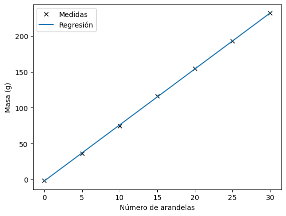

```python
def lineal(x, pendiente, ordenada_origen):
    """Dado x calcula y(x) asociado a una correlación linear"""
    return np.multiply(pendiente, x) + ordenada_origen

plt.plot(numero_arandelas, masa_arandelas, 'x', label='Medidas', color="black")
masas_arandelas_teoricas = lineal(numero_arandelas, res.slope, res.intercept)
plt.plot(numero_arandelas, masas_arandelas_teoricas, '-', label='Regresión')
plt.xlabel("Número de arandelas")
plt.ylabel("Masa (g)")
plt.legend()
plt.show()
```

El error de cero que estamos forzando (aunque apenas se percibe en el gráfico por ser prácticamente despreciable frente al rango de las masas) no influye en la pendiente de la recta de regresión de los $n$ puntos. El valor de la masa promedio por arandela será la pendiente de esta recta de regresión. Por tanto:

$$\overline{m_1} = 7.808g$$

Cuya incertidumbre asociada es $u_{m_1} = 0.040g$ y por tanto:

$$m_1 = \overline{m_1} \pm u_{m_1} = 7.808 \pm 0.040 \text{ g}$$

```python
print(f"Pendiente (m): {res.slope:.3f} \u00B1 {res.stderr:.3f} g")
print(f"Ordenada en el origen (b): {res.intercept:.1f} \u00B1 {res.intercept_stderr:.1f} g")
```

```
Pendiente (m): 7.808 ± 0.040 g
Ordenada en el origen (b): -2.1 ± 0.7 g
```

```python
# Masa y sus respectiva incertidumbre (común a I y II)
masa = 7.808   # g
u_masa = 0.040 # g
```

#### 6.2.D CÁLCULO DE LA DENSIDAD Y SUS RESPECTIVAS INCERTIDUMBRES

```python
rho_I = masa / V_I   # g/mm^3
rho_II = masa / V_II # g/mm^3
```

```python
def propagacion_incertidumbre_rho(rho, m, u_m, v, u_v):
    return rho * np.sqrt((u_m / m)**2 + (u_v / v)**2)
```

```python
u_rho_I = propagacion_incertidumbre_rho(rho_I, masa, u_masa, V_I, u_VI)
print(f"ρI = {rho_I} ± {u_rho_I} g/mm^3")
rho_II = masa / V_II
u_rho_II = propagacion_incertidumbre_rho(rho_II, masa, u_masa, V_II, u_VII)
print(f"ρII = {rho_II} ± {u_rho_II} g/mm^3")
```

```
ρI = 0.007860539848346346 ± 4.026923071793121e-05 g/mm^3
ρII = 0.006598138865133636 ± 3.380199655160499e-05 g/mm^3
```